# Ezekiel_ESS______New species added

Ezekiel/Julia/Derek

2023-04-17

Running Eastern Scotian Model to steady State

Load Libraries first

```r
#remotes::install_github("sizespectrum/mizerExperimental")
library(mizer)
library("assertthat")
library("optimParallel")
library("here")
library("tidyr")
library(dplyr)
#library("nloptr")
library(mizerExperimental)
library(tidyverse)
#library(mizerHowTo)
library(pbapply)
library(openair)
library(patchwork)
library(dplyr)
library(tidyr)
library(tibble)
library(zoo)
library(RColorBrewer)
```

Set up directories

Read in Species Parameters

```r
species_lookup <- c(
  "Gadus morhua"                   = "Atlantic Cod",
  "Melanogrammus aeglefinus"       = "Haddock",
  "Urophycis tenuis"               = "White Hake",
  "Urophycis chuss"                = "Red Hake",
  "Merluccius bilinearis"          = "Silver Hake",
  "Pollachius virens"              = "Pollock",
  "Sebastes fasciatus"             = "Redfish Unseparated",
  "Hippoglossoides platessoides"   = "American Plaice",
  "Myzopsetta ferruginea"          = "Yellowtail Flounder",  ## Limanda ferruginea
  "Glyptocephalus cynoglossus"     = "Witch Flounder",
  "Clupea harengus"                = "Atlantic Herring",
  "Mallotus villosus"              = "Capelin",
  "Amblyraja radiata"              = "Thorny Skate",
  "Leucoraja ocellata"             = "Winter Skate",
  "Squalus acanthias"              = "Spiny Dogfish",
  "Lophius americanus"             = "Monkfish",
  "Ammodytes dubius"               = "Sand Lance",
  "Myoxocephalus octodecemspinosus" = "Longhorn Sculpin",
  "Hippoglossus hippoglossus"      = "Atlantic Halibut")

species_order <- c( "Atlantic Cod", "Haddock", "White Hake", "Red Hake", "Silver Hake",
                    "Pollock", "Redfish Unseparated","American Plaice", "Yellowtail Flounder",
                    "Witch Flounder", "Atlantic Herring","Capelin", "Thorny Skate",
                    "Winter Skate", "Spiny Dogfish", "Monkfish", "Sand Lance",
                    "Longhorn Sculpin",  "Atlantic Halibut")

external_species_info <- read.csv("Ess_data/ESS_species_params.csv") |>
 #Hartvig et al. 2011 ; preferred (roughly) should be realised ppmr divided by 2
# I think min_ppmr_adj or min_ppmr probably best reflection of "preferred" ppmr; else could use a box predation kernel
 select(-beta) |>
  rename(beta = min_ppmr_adj) |>
  select(Species, w_max, w_mat, w_min, l_mat, beta, sigma, k_vb, a, b, age_mat) |>
  mutate(across(where(is.numeric), ~ round(., 3)),
  Species = factor(recode(Species, !!!species_lookup), levels = species_order)) |>
  filter(!is.na(Species)) |> arrange(Species) |> mutate(Species = as.character(Species)) |>
  rename(species = Species)

years_to_use<-as.character(1978:1985)  #Assign years for the reference period, to initialise steady state model before applying dynamics over whole period

# #The initial Rmax was estimated from an empirical equation as in (Blanchard et al., 2014)
external_species_info <- external_species_info |> mutate(R_max = 10^13 * w_max^-1.5)
```

Read in DFO Summer RV survey abundance and biomass data from DFO Maritimes region data team, subset depth strata to include only 4VsW (in line with Bundy et al. EwE spatial domain).

Calculate the minimum length and weight cutoffs from length distributions for us in model, to account for the fact that smaller sizes not selected by the RV gear. Maybe should add a maximum length and weight as well.

```r
stat <- read.csv("Ess_data/LF_Biomass_Abund.csv")

# ── LOOKUP: RAW SURVEY NAME -> MODEL NAME ────────────────────────────────────
species_code_lookup <- c(
  "COD(ATLANTIC)"             = "Atlantic Cod",
  "HADDOCK"                   = "Haddock",
  "WHITE HAKE"                = "White Hake",
  "SILVER HAKE"               = "Silver Hake",
  "POLLOCK"                   = "Pollock",
  "REDFISH UNSEPARATED"       = "Redfish Unseparated",
  "AMERICAN PLAICE"           = "American Plaice",
  "YELLOWTAIL FLOUNDER"       = "Yellowtail Flounder",
  "SPINY DOGFISH"             = "Spiny Dogfish",
  "HALIBUT(ATLANTIC)"         = "Atlantic Halibut",
  "SQUIRREL OR RED HAKE"      = "Red Hake",
  "MONKFISH,GOOSEFISH,ANGLER" = "Monkfish",
  "NORTHERN SAND LANCE"       = "Sand Lance",
  "WITCH FLOUNDER"            = "Witch Flounder",
  "HERRING(ATLANTIC)"         = "Atlantic Herring",
  "THORNY SKATE"              = "Thorny Skate",
  "WINTER SKATE"              = "Winter Skate",
  "LONGHORN SCULPIN"          = "Longhorn Sculpin",
  "CAPELIN"                   = "Capelin")


# Species lookup
stat2 <- stat |>
  filter(YEAR >= 1978, YEAR <= 2024) |>
  select(
    depth_strata = STRAT,
    year = YEAR,
    species_name_raw = COMMON_NAME,
    length_cm = FLEN,
    abundance = Abundance_Strata) |>
  mutate(
    length_cm = ifelse(
      species_name_raw == "HERRING(ATLANTIC)", # herring looks like measured in mm!
      length_cm / 10,
      length_cm),
    species_name = species_code_lookup[species_name_raw]) |>
  filter(!is.na(species_name))

# 1. Sum abundance across depth strata by species, year and length
lf_year_length <- stat2 %>%
  group_by(species_name, year, length_cm) %>%
  summarise(
    abundance = sum(abundance, na.rm = TRUE),
    .groups = "drop")


weighted_quantile <- function(x, w, probs = 0.05) {
  ok <- is.finite(x) & is.finite(w) & w > 0
  x <- x[ok]
  w <- w[ok]
  if (length(x) == 0) return(NA_real_)

  o <- order(x)
  x <- x[o]
  w <- w[o]

  cw <- cumsum(w) / sum(w)
  x[which(cw >= probs)[1]]
}

annual_length_quantiles <- lf_year_length %>%
  group_by(species_name, year) %>%
  summarise(
    q01_length_cm = weighted_quantile(length_cm, abundance, 0.01),
    q05_length_cm = weighted_quantile(length_cm, abundance, 0.05),
    q50_length_cm = weighted_quantile(length_cm, abundance, 0.50),
    .groups = "drop")

cutoff_quantile_summary <- annual_length_quantiles %>%
  group_by(species_name) %>%
  summarise(
    cutoff_q01_median = median(q01_length_cm, na.rm = TRUE),
    cutoff_q01_q75 = quantile(q01_length_cm, 0.75, na.rm = TRUE),
    cutoff_q05_median = median(q05_length_cm, na.rm = TRUE),
    .groups = "drop")

cutoff_quantile_summary
```

```
## # A tibble: 19 × 4
##    species_name        cutoff_q01_median cutoff_q01_q75 cutoff_q05_median
##    <chr>                           <dbl>          <dbl>             <dbl>
##  1 American Plaice                     9           10                  11
##  2 Atlantic Cod                       11           14.5                18
##  3 Atlantic Halibut                   27           31                  32
##  4 Atlantic Herring                   10           16                  19
##  5 Capelin                             9           11                  10
##  6 Haddock                             8           15.5                 9
##  7 Longhorn Sculpin                    8            9                  12
##  8 Monkfish                           14           17.5                20
##  9 Pollock                            27           30.5                31
## 10 Red Hake                           14           15                  17
## 11 Redfish Unseparated                11           12.5                14
## 12 Sand Lance                          9           13.5                12
## 13 Silver Hake                        13           14                  15
## 14 Spiny Dogfish                      46           48.5                52
## 15 Thorny Skate                       13           13                  15
## 16 White Hake                         21           24                  28
## 17 Winter Skate                       16           28                  27
## 18 Witch Flounder                     10           12                  16
## 19 Yellowtail Flounder                 9           13                  13
```

[figure not shown]

```r
# Overall abundance-weighted length distributions
lf_overall <- lf_year_length %>%
  mutate(
    length_bin = floor(length_cm / 2) * 2
  )%>%
  group_by(species_name, length_bin) %>%
  summarise(
    abundance = sum(abundance, na.rm = TRUE),
    .groups = "drop"
  ) %>%
  filter(!is.na(species_name), !is.na(length_bin), abundance > 0)

# Optional: derive thresholds from q05_q75
length_thresholds <- cutoff_quantile_summary %>%
  transmute(
    species_name,
    threshold_cm = cutoff_q01_q75)



# Plot
ggplot(lf_overall, aes(x = length_bin, y = abundance)) +
  geom_col(width = 1.8) +
  geom_vline(
    data = length_thresholds,
    aes(xintercept = threshold_cm),
    linetype = "dashed",
    linewidth = 0.6 ) +
  facet_wrap(~species_name, scales = "free") +
  theme_bw() +
  labs(
    x = "Length (cm)",
    y = "Total stratified abundance",
    title = "Abundance-weighted length distributions across all years and strata",
    subtitle = "Dashed lines show q75 of annual abundance-weighted 5th percentile length")
```

```r
# ── LOWER SIZE CUTOFF FOR ESTIMATING BIOMASS ────────────────────────────────────────────────────────────
biomass_cutoff <- cutoff_quantile_summary |>
  left_join(
    external_species_info |>
      select(species, a, b),
    by = c("species_name" = "species")) |>
  mutate(
    biomass_cutoff = round(a * cutoff_q01_q75 ^ b, 1)) |>
  select(
    species = species_name,
    biomass_cutoff)

# ── JOIN BACK TO SPECIES INFO ─────────────────────────────────────────────────
external_species_info <- external_species_info |>
  left_join(
    biomass_cutoff,
    by = "species")


# CHeck if need to adjust max_w for some species (too small max_w from RFishBase)

# Survey maximum lengths
survey_max_lengths <- stat2 %>%
  group_by(species_name) %>%
  summarise(
    survey_max_length_cm = max(length_cm, na.rm = TRUE),
    q99_length_cm = weighted_quantile(length_cm, abundance, 0.99),
    .groups = "drop")

# Convert FishBase max lengths to max weights using W = aL^b
max_weight_comparison <- survey_max_lengths %>%
  left_join(
    external_species_info %>% select(species, a, b, w_max),
    by = c("species_name" = "species")) %>%
  mutate(
    survey_max_weight_g = a * survey_max_length_cm ^ b,
    biomass_cutoffHigh = a * q99_length_cm ^ b,
    w_max_ratio = survey_max_weight_g / w_max, # survey max w, proportion of model w_max, should be less than 1
    q99_ratio =  biomass_cutoffHigh / w_max  #99th percentile of max weights, should be less than 1
  )

max_weight_comparison
```

```
## # A tibble: 19 × 10
##    species_name        survey_max_length_cm q99_length_cm     a     b    w_max
##    <chr>                              <dbl>         <dbl> <dbl> <dbl>    <dbl>
##  1 American Plaice                       74          48   0.006  3.06   4742.
##  2 Atlantic Cod                         159          75   0.007  3.08  82637.
##  3 Atlantic Halibut                     207         140   0.005  3.17 162387.
##  4 Atlantic Herring                      42          31.5 0.005  3.1     733.
##  5 Capelin                               30          18   0.004  3.21     54.5
##  6 Haddock                               83          52   0.007  3.08  13539.
##  7 Longhorn Sculpin                      63          35   0.007  3.13   1108.
##  8 Monkfish                             116         110   0.014  2.98  21675.
##  9 Pollock                              111          85   0.007  3.07  20408.
## 10 Red Hake                              69          46   0.004  3.11   1857.
## 11 Redfish Unseparated                   61          36   0.01   3.13   1753.
## 12 Sand Lance                            32          25   0.002  3.05     44.0
## 13 Silver Hake                           69          35   0.005  3.11   3383.
## 14 Spiny Dogfish                        106          84   0.003  3.07  16852.
## 15 Thorny Skate                         114          81   0.003  3.25  11718.
## 16 White Hake                           130          83   0.004  3.16  20482.
## 17 Winter Skate                         109          97   0.003  3.24  29549.
## 18 Witch Flounder                        66          52   0.004  3.08   1339.
## 19 Yellowtail Flounder                   54          39   0.007  3.07   2426.
## # ℹ 4 more variables: survey_max_weight_g <dbl>, biomass_cutoffHigh <dbl>,
## #   w_max_ratio <dbl>, q99_ratio <dbl>
```

```r
max_weight_comparison <- max_weight_comparison |> select(species = species_name, biomass_cutoffHigh  )


# ── JOIN BACK TO SPECIES INFO ─────────────────────────────────────────────────
external_species_info <- external_species_info |> left_join(max_weight_comparison, by = "species" )
```

Copy species life history parameters into the species parameters for the model

```r
external_species_info <-select(external_species_info,c("species","w_max","w_mat", "w_min","beta" ,"sigma" ,"a","b","age_mat","R_max" , "biomass_cutoff", "biomass_cutoffHigh"))
```

REDO THIS USING DATA ABOVE: Read in Abundance and Biomass at length from DFO RV Summer Survey (from DFO Maritimes region data team, 4VsW - see methods) convert from KG to grams. Prior to calculation need to truncate the biomass at length by the same length cut_off used in the model. Rename columns

```r
biomass_obs <- read.csv("Ess_data/DFO_Biomass_selected_species.csv")
biomass_obs[, -1] <- biomass_obs[, -1] * 1e3
colnames(biomass_obs) <- gsub("\\s+", " ", trimws(gsub("\\.", " ", colnames(biomass_obs))))
colnames(biomass_obs)[colnames(biomass_obs) == "YEAR"] <- "Year"
biomass_obs <- biomass_obs %>% select(Year, any_of(species_order))
biomass_obs[is.na(biomass_obs)] <- 0


## FORAGE FISH CATCHABILITY ASSUMPTION: scale up biomass herring X 50 , sandeel, and capelin by factor of 200 - TEST SENSITIVITY OF RUNS, based approximately on Harly et al. 2001 and Bundy et al.
biomass_obs <- biomass_obs %>%
  mutate(`Atlantic Herring` = `Atlantic Herring` * 50,
    `Sand Lance` = `Sand Lance` * 200,
    `Capelin` = `Capelin` * 200)
```

To intialise model need to time-average biomasses between 1978 and 1985 (prior to any detectable trends in species, relatively more stable period)

```r
library(reshape2)
#Aggregate observed biomass to mean biomass
biomass_obs_sub <- subset(biomass_obs, Year >= 1978 & Year <= 2024)
biomass_ts <- reshape2::melt(biomass_obs_sub, id.vars = 1)
names(biomass_ts)<-c("Year","Species","Biomass")
saveRDS(biomass_ts, "Ess_data/biomass_ts.RDS")
## Arithmetic mean
# mean_biomass_obs <- subset(biomass_ts, Year<=max(years_to_use))%>%
#   group_by(Species)%>% summarise(biomass_observed =mean(Biomass,  na.rm = T))
## Geom mean
mean_biomass_obs <- subset(biomass_ts, Year <= max(years_to_use)) %>%
  group_by(Species) %>% summarise( biomass_observed = exp(mean(log(Biomass[Biomass > 0]), na.rm = TRUE)))

mean_biomass_obs$biomass_observed<- ifelse(is.nan( mean_biomass_obs$biomass_observed),NA,  mean_biomass_obs$biomass_observed)
```

Read in catch data/Subset and average the catch data

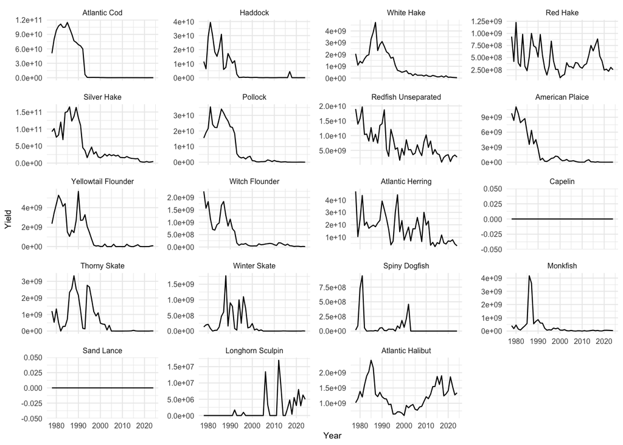

```r
catches <- readRDS("Ess_data/new_NAFO_4VW_Catches.RDS")
catches <- as.data.frame(catches)
catches[is.na(catches)] <- 0

catches$Capelin <- 0 # No capelin fished just as sandlance
yield_ts <- catches |>
  filter(Year %in% 1978:2024) |>
  pivot_longer(cols = -Year, names_to = "Species", values_to = "Yield") |>
  mutate(Yield = replace_na(Yield, 0))

saveRDS(yield_ts, "Ess_data/yield_ts.RDS")

# Check plot
yield_ts$Species <- factor(yield_ts$Species, levels = unique(yield_ts$Species))

## Check plot
yield_ts$Species <- factor(yield_ts$Species,levels = unique(yield_ts$Species))
ggplot(yield_ts, aes(x = Year, y = Yield)) + geom_line(linewidth = 0.4) +
  facet_wrap(~ Species, scales = "free_y", ncol = 4) +
  theme_minimal(base_size = 8) +
  theme(
    strip.text = element_text(size = 6),
    axis.text = element_text(size = 6), axis.title = element_text(size = 7),
    panel.spacing = unit(0.5, "lines") ) +labs(x = "Year", y = "Yield")
```

```r
## Aggregate to mean observed catch
## Aritmetric mean
# mean_catch_nafo <- subset(yield_ts, Year<=max(years_to_use))%>%
#   group_by(Species)%>%
#   summarise(yield_observed =mean(Yield,  na.rm = T))
## Geom mean
mean_catch_nafo <- subset(yield_ts, Year <= max(years_to_use)) %>%
  group_by(Species) %>% summarise(yield_observed = exp(mean(log(Yield[Yield > 0]), na.rm = TRUE))) %>%
  ungroup() %>% arrange(factor(Species, levels = species_order))

# set sandlance and capelin catches to NA; assume not fished (only sporadic catches)
mean_catch_nafo$yield_observed[17] <- 0 # Sand Lance
mean_catch_nafo$yield_observed[12] <- 0  # Capelin
mean_catch_nafo$yield_observed[18] <- 0  # Longthorn scuplin
```

Introduce catch and ssb into data minimum size in survey - assume 10 but check the DFO spreadsheet

```r
#Assign obeserved biomas and catches to species
external_species_info$biomass_observed <- mean_biomass_obs$biomass_observed
external_species_info$yield_observed <- mean_catch_nafo$yield_observed
```

Set up fishing gear parameters

```r
#load gear and knife_edge_gear
fishing_type = read.csv("Ess_data/new.gear_params.csv")
names(fishing_type)[1] = "species"
gear_params <- fishing_type
gear_names <- gear_params$gear
```

Set up fishing gear parameters

```r
fishing_type <- read.csv("Ess_data/new.gear_params.csv")
names(fishing_type)[1] <- "species"

new_seal <- read.csv("Ess_data/seal_gear_params.csv")
new_seal$catchability <- new_seal$catchability / 10   # Reduce initial seal catchability

# Gaussian size-selectivity function (used by mizer internally)
gaussian_sizeweight <- function(w, species_params, w_opt, sigma, ...) {
  exp(-0.5 * ((log(w) - log(w_opt)) / sigma)^2)
}

rownames(fishing_type) <- paste(fishing_type$species, fishing_type$gear, sep = ", ")
rownames(new_seal)     <- paste(new_seal$species,     new_seal$gear,     sep = ", ")
updated_gp <- bind_rows(fishing_type, new_seal)
```

Copy species life history parameters into the species parameters for the model

```r
external_species_info <- select(external_species_info, c("species","w_max","w_mat",
  "w_min","beta","sigma","a","b","age_mat","R_max","biomass_cutoff","biomass_cutoffHigh",
  "biomass_observed","yield_observed"))
```

Set up params then set up initial catchability using this mean relative effort and catchability of 1 as initial value only - BUT WILL ESTIMATE LATER

```r
params <- newMultispeciesParams(external_species_info,interaction = NULL, resource_dynamics = "resource_semichemostat",kappa = 1e11, gear_params = updated_gp)
```

```
## Because you have n != p, the default value for `h` is not very good.
## No ks column so calculating from critical feeding level.
## Using z0 = z0pre * w_max ^ z0exp for missing z0 values.
## Using f0, h, lambda, kappa and the predation kernel to calculate gamma.
```

```r
resource_params(params)$w_pp_cutoff <- 100

gear_params(params)$yield_observed <- mean_catch_nafo$yield_observed
```

## Next action for attention.

# Julia help on this …plss

```r
# ══════════════════════════════════════════════════════════════════════════════
# 4VsW MULTISPECIES INTERACTION MATRIX
# Schoener's D spatial overlap → guild structure → mizer interaction matrix
# Strata 444–466 | 19 species | Cook & Bundy 2010
# ══════════════════════════════════════════════════════════════════════════════

library(tidyverse)
library(factoextra)
```

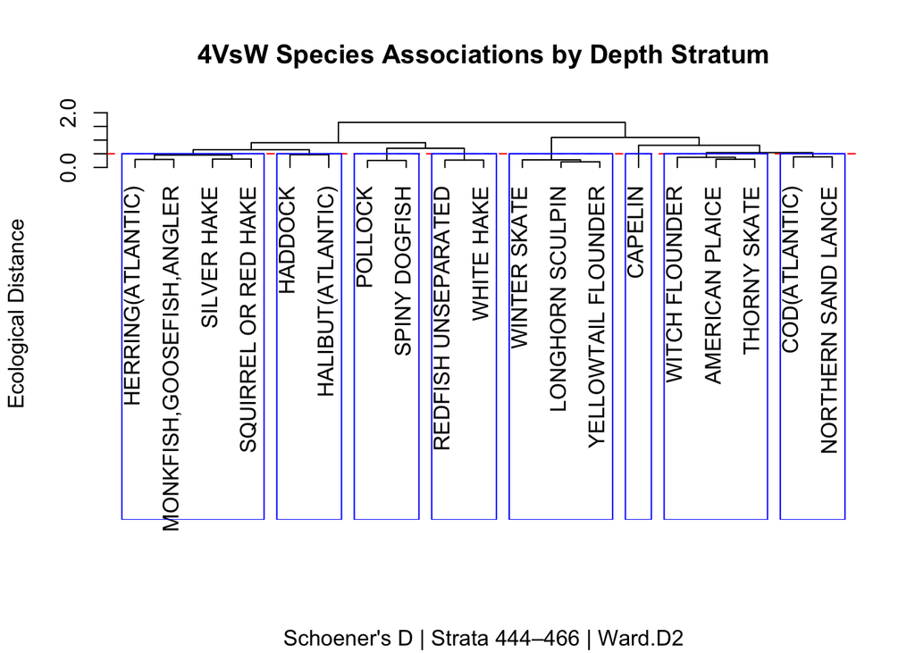

```r
library(tidyverse)
library(factoextra)

# ── 1. LOAD DATA ──────────────────────────────────────────────────────────────
stat <- read.csv("Ess_data/LF_Biomass_Abund.csv")

selected_spp_names <- c(
    "COD(ATLANTIC)", "HADDOCK", "REDFISH UNSEPARATED",
    "AMERICAN PLAICE", "SILVER HAKE", "MONKFISH,GOOSEFISH,ANGLER",
    "WHITE HAKE", "THORNY SKATE", "WINTER SKATE", "POLLOCK",
    "YELLOWTAIL FLOUNDER", "LONGHORN SCULPIN", "SQUIRREL OR RED HAKE",
    "HERRING(ATLANTIC)", "NORTHERN SAND LANCE", "SPINY DOGFISH",
    "HALIBUT(ATLANTIC)", "CAPELIN", "WITCH FLOUNDER"
)

# ── 2. BUILD STRATUM MATRIX (clean 4VsW domain only) ─────────────────────────
stratum_matrix <- stat %>%
    filter(COMMON_NAME %in% selected_spp_names) %>%
    filter(!is.na(STRAT), STRAT != "") %>%
    filter(suppressWarnings(as.numeric(STRAT)) >= 444,
           suppressWarnings(as.numeric(STRAT)) <= 466) %>%
    group_by(STRAT, COMMON_NAME) %>%
    summarise(biomass = sum(Biomass_Strata_KG, na.rm = TRUE), .groups = "drop") %>%
    pivot_wider(names_from = COMMON_NAME, values_from = biomass, values_fill = 0) %>%
    column_to_rownames("STRAT")

# ── 3. NORMALIZE & SCHOENER'S D ───────────────────────────────────────────────
col_sums <- colSums(stratum_matrix)
col_sums[col_sums == 0] <- 1
dist_norm <- sweep(stratum_matrix, 2, col_sums, "/")

# Schoener's D: 1 - (manhattan distance / 2)
schoener_matrix <- 1 - (as.matrix(dist(t(dist_norm), method = "manhattan")) / 2)
diag(schoener_matrix) <- 1

# ── 4. OPTIONAL: SPARSE SPECIES OVERLAP REPORT ────────────────────────────────
# Define sparse species to inspect, or leave empty to skip
sparse <- character(0)
# e.g. sparse <- c("CAPELIN", "NORTHERN SAND LANCE")

if (length(sparse) > 0) {
    cat("\n── Overlap values for sparse species ──\n")
    for (sp in sparse) {
        cat("\n", sp, ":\n", sep = "")
        print(round(sort(schoener_matrix[sp, ], decreasing = TRUE), 3))
    }
}

# ── 5. HIERARCHICAL CLUSTERING ────────────────────────────────────────────────
d   <- as.dist(1 - schoener_matrix)
fit <- hclust(d, method = "ward.D2")

# ── 6. BASE R DENDROGRAM ──────────────────────────────────────────────────────
plot(fit,
     main = "4VsW Species Associations by Depth Stratum",
     xlab = "",
     sub  = "Schoener's D | Strata 444–466 | Ward.D2",
     ylab = "Ecological Distance",
     hang = -1)
abline(h = 0.5, col = "red", lty = 2)
rect.hclust(fit, h = 0.5, border = "blue")
```

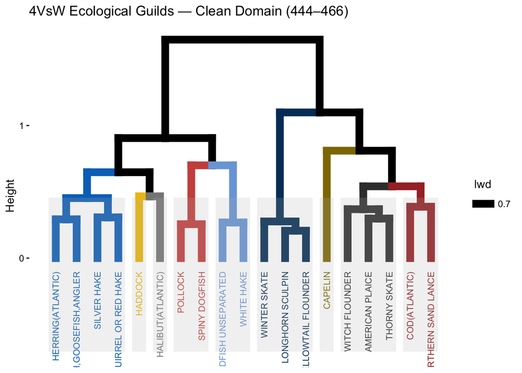

```r
# ── 7. GGPLOT DENDROGRAM ──────────────────────────────────────────────────────
fviz_dend(fit,
          h         = 0.5,
          type      = "rectangle",
          rect      = TRUE,
          rect_fill = TRUE,
          k_colors  = "jco",
          cex       = 0.6,
          main      = "4VsW Ecological Guilds — Clean Domain (444–466)")
```

```r
# ── 8. GUILD ASSIGNMENTS ──────────────────────────────────────────────────────
clusters <- cutree(fit, h = 0.5)
cat("\n── Guild assignments (h = 0.5) ──\n")
```

```
##
## ── Guild assignments (h = 0.5) ──
```

```r
print(sort(clusters))
```

```
##           AMERICAN PLAICE              THORNY SKATE            WITCH FLOUNDER
##                         1                         1                         1
##                   CAPELIN             COD(ATLANTIC)       NORTHERN SAND LANCE
##                         2                         3                         3
##                   HADDOCK         HALIBUT(ATLANTIC)         HERRING(ATLANTIC)
##                         4                         4                         5
## MONKFISH,GOOSEFISH,ANGLER               SILVER HAKE      SQUIRREL OR RED HAKE
##                         5                         5                         5
##          LONGHORN SCULPIN              WINTER SKATE       YELLOWTAIL FLOUNDER
##                         6                         6                         6
##                   POLLOCK             SPINY DOGFISH       REDFISH UNSEPARATED
##                         7                         7                         8
##                WHITE HAKE
##                         8
```

```r
# ── 6. GUILD DEFINITIONS ──────────────────────────────────────────────────────
# Note: White Hake appears in both mid_water and piscivores (intentional —
# reflects its dual role as benthopelagic predator)

pelagics     <- c("Atlantic Herring", "Capelin", "Silver Hake","Red Hake", "Sand Lance")
mid_water    <- c("White Hake", "Pollock", "Redfish Unseparated")
benthivores  <- c("Haddock", "American Plaice", "Yellowtail Flounder","Witch Flounder", "Longhorn Sculpin")
piscivores   <- c("Atlantic Cod", "Spiny Dogfish", "White Hake", "Monkfish")
large_elasmo <- c("Thorny Skate", "Winter Skate", "Atlantic Halibut")

# Sanity check — all 19 params species covered (overlaps allowed for White Hake)
sp           <- rownames(interaction_matrix(params))
all_assigned <- unique(c(pelagics, mid_water, benthivores, piscivores, large_elasmo))
missing      <- setdiff(sp, all_assigned)
not_in_params <- setdiff(all_assigned, sp)


# ── 7. BUILD MIZER INTERACTION MATRIX ─────────────────────────────────────────
inter <- matrix(
    0.5,
    nrow     = nrow(species_params(params)),
    ncol     = nrow(species_params(params)),
    dimnames = list(species_params(params)$species,
                    species_params(params)$species))
diag(inter) <- 0.5

# ── Within-guild overlap ───────────────────────────────────────────────────────
inter[pelagics,    pelagics]    <- 0.35
inter[benthivores, benthivores] <- 0.30
inter[piscivores,  piscivores]  <- 0.30
inter[mid_water,   mid_water]   <- 0.25

# ── Predator–prey ──────────────────────────────────────────────────────────────
inter[piscivores,  pelagics]    <- 0.50
inter[piscivores,  mid_water]   <- 0.35
inter[piscivores,  benthivores] <- 0.25
inter[benthivores, pelagics]    <- 0.10
inter[mid_water,   pelagics]    <- 0.35
inter[mid_water,   benthivores] <- 0.20

# ── Large elasmobranchs / halibut ─────────────────────────────────────────────
inter[, large_elasmo]                <- 0.15
inter[piscivores,  large_elasmo]     <- 0.25
inter["Spiny Dogfish", large_elasmo] <- 0.10

# ── Species-specific ───────────────────────────────────────────────────────────
inter["White Hake",       benthivores]       <- 0.15
inter["White Hake",       "Sand Lance"]      <- 0.60
inter["Haddock",          pelagics]          <- 0.15
inter["Haddock",          piscivores]        <- 0.05
inter["Atlantic Halibut", pelagics]          <- 0.15
inter["Atlantic Halibut", benthivores]       <- 0.50
inter["Thorny Skate",     "Winter Skate"]    <- 0.10
inter["Winter Skate",     "Thorny Skate"]    <- 0.10

# ── Stability adjustments ──────────────────────────────────────────────────────
inter[, "Spiny Dogfish"]                      <- 0.02
inter[, "American Plaice"]                    <- inter[, "American Plaice"]        * 0.60
inter[, "Redfish Unseparated"]                <- inter[, "Redfish Unseparated"]    * 0.50
inter["Spiny Dogfish",    "Spiny Dogfish"]    <- 0.05
inter["Atlantic Cod",     "Redfish Unseparated"] <- 0.10
inter["White Hake",       "Redfish Unseparated"] <- 0.10
inter["Monkfish",         "Redfish Unseparated"] <- 0.10

# ── Apply to params ───────────────────────────────────────────────────────────
params <- setInteraction(params, inter)          # was: inter_matrix

# inter_df only for heatmap plotting
inter_df <- as.data.frame(as.table(inter))       # was: inter_matrix
colnames(inter_df) <- c("Predator", "Prey", "Interaction")
```

## Predator–prey interaction matrix

```r
inter= inter_df
inter_long <- melt(inter, varnames = c("Predator", "Prey"), value.name = "InteractionStrength")
```

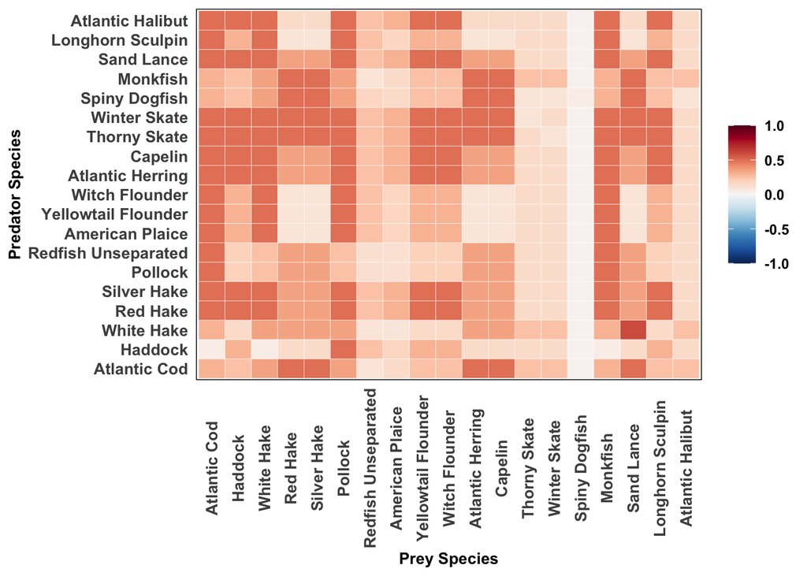

```r
pal <- rev(brewer.pal(11, "RdBu"))

heatmap_plot <- ggplot(inter_long, aes(x = Prey, y = Predator, fill = InteractionStrength)) +
  geom_tile(color = "white", linewidth = 0.1) +
  scale_fill_gradientn(colors = pal, limits = c(-1, 1), breaks = c(-1, -0.5, 0, 0.5, 1)) +
  labs(x = "Prey Species", y = "Predator Species") +
  theme_minimal(base_family = "Arial") +
  theme(
    axis.text.x      = element_text(angle = 90, hjust = 0.5, vjust = 0.5, size = 10, face = "bold"),
    axis.text.y      = element_text(size = 10, face = "bold"),
    axis.title       = element_text(size = 10, face = "bold"),
    legend.title     = element_blank(),
    legend.text      = element_text(size = 9, face = "bold"),
    panel.grid       = element_blank(),
    panel.border     = element_rect(color = "black", fill = NA, linewidth = 0.5),
    panel.background = element_blank()
  )

heatmap_plot
```

## Set Initial Fishing Effort

## Read the fishing history data/set fishing into params from NAFO

## set intial effort as mean_effort - SEALS MISSING

```r
effort_final       <- read.csv("Ess_data/effort_gear_with_seals.csv", row.names = 1)
effort_final$Year  <- as.numeric(rownames(effort_final))

mean_effort        <- colMeans(effort_final[effort_final$Year %in% years_to_use, ])

# FIX: use initial_effort(params_steady) later for projectToSteady — here we
# just set the five fishing gears (columns 1:5, excluding Year)
initial_effort(params) <- unlist(mean_effort[1:5])
```

## Run to Steady State

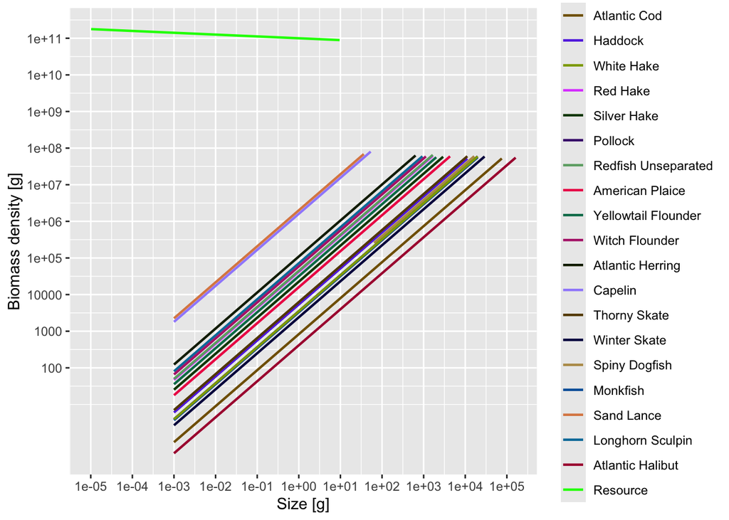

```r
plotSpectra(params, power = 2)   # Pre-steady-state check
```

```r
params <- steady(params)
```

```
## Simulation run did not converge after 99 years. Value returned by the distance function was: 0.0312545716717637
```

```r
plotlySpectra(params, power = 2)
```

[interactive chart not shown]

Inspect plots via: tuneParams(params) check size spectra of resource and community line up, growth curves look reasonably similar to von Bertalanffy, diets look reasonable, etc.

## Calibrate Biomass Scale

```r
params <- calibrateBiomass(params)
params <- steady(params)
```

```
## Convergence was achieved in 51 years.
```

```r
params <- calibrateBiomass(params)
params <- steady(params)
```

```
## Convergence was achieved in 1.5 years.
```

```r
plotlySpectra(params, power = 2)
```

[interactive chart not shown]

```r
plotlyFeedingLevel(params)
```

[interactive chart not shown]

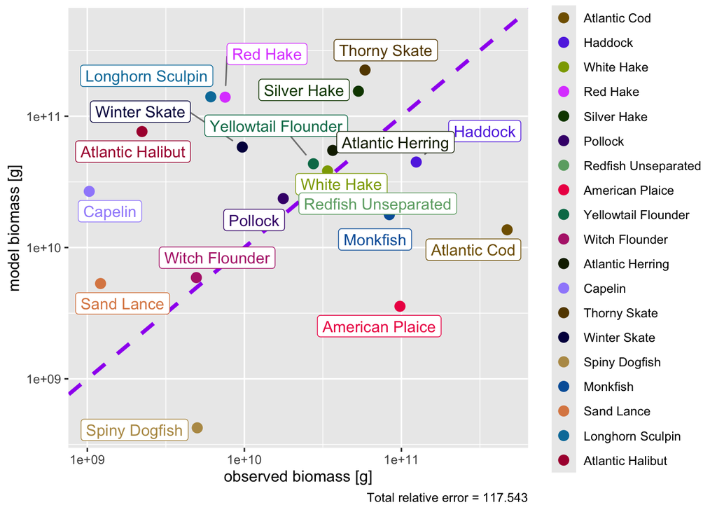

```r
plotBiomassObservedVsModel(params)
```

Rescale Species Spectra, Rince and repeat (till convergence is achieved in 1.5 years)

```r
# Iteratively improve the calibration by adjusting model parameters
# to better match observed biomasses, and then re-solving for steady state
for (i in 1:25) {
  params <- params |>
    matchBiomasses() |>  # Adjust species parameters to better match observed biomasses
    #matchGrowth() |>
    steady()             # Recalculate the steady-state solution
}
```

```
## Convergence was achieved in 96 years.
```

```
## Convergence was achieved in 33 years.
```

```
## Convergence was achieved in 15 years.
```

```
## Convergence was achieved in 12 years.
```

```
## Convergence was achieved in 1.5 years.
## Convergence was achieved in 1.5 years.
## Convergence was achieved in 1.5 years.
## Convergence was achieved in 1.5 years.
## Convergence was achieved in 1.5 years.
## Convergence was achieved in 1.5 years.
## Convergence was achieved in 1.5 years.
## Convergence was achieved in 1.5 years.
## Convergence was achieved in 1.5 years.
## Convergence was achieved in 1.5 years.
## Convergence was achieved in 1.5 years.
## Convergence was achieved in 1.5 years.
## Convergence was achieved in 1.5 years.
## Convergence was achieved in 1.5 years.
## Convergence was achieved in 1.5 years.
## Convergence was achieved in 1.5 years.
## Convergence was achieved in 1.5 years.
## Convergence was achieved in 1.5 years.
## Convergence was achieved in 1.5 years.
## Convergence was achieved in 1.5 years.
## Convergence was achieved in 1.5 years.
```

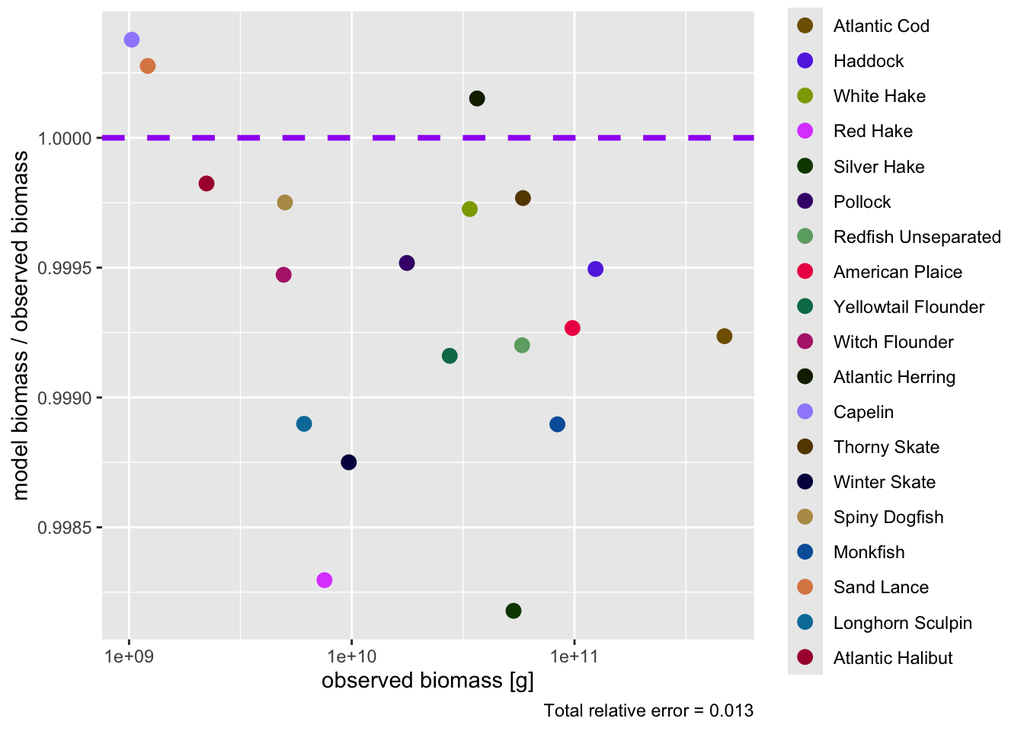

```r
# Plot comparison of model-predicted vs observed biomass
# - ratio = TRUE: plots the ratio (model / observed), ideal value is 1
# - labels = FALSE: do not display species names on the plot
plotBiomassObservedVsModel(params, ratio = TRUE, labels = FALSE)
```

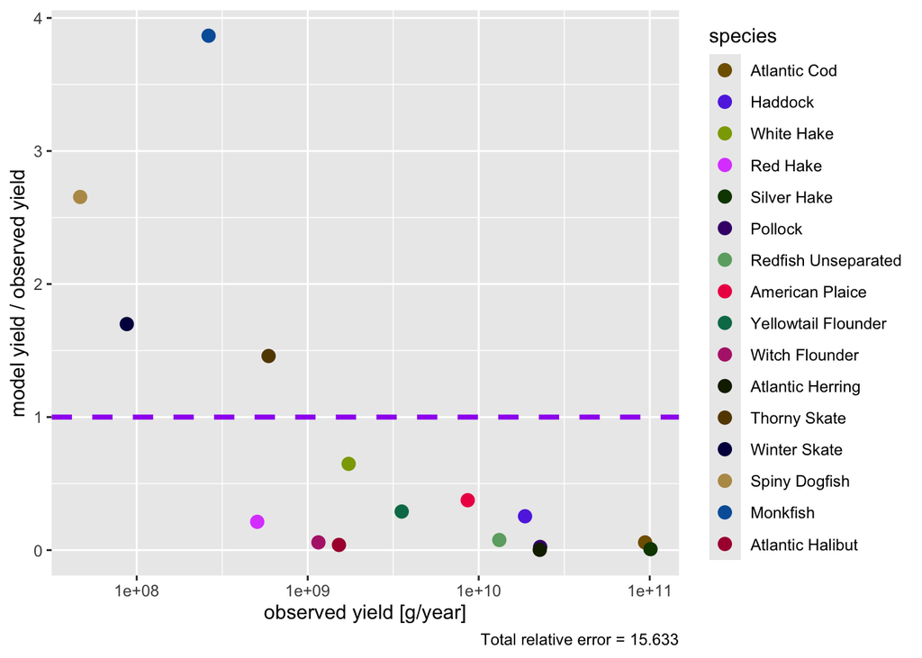

```r
# Plot comparison of model-predicted vs observed yield (catch)
# - ratio = TRUE: shows how well the model predicts catch relative to observed data
# - labels = FALSE: cleaner plot without species labels
plotYieldObservedVsModel(params, ratio = TRUE, labels = FALSE)
```

```r
# Plot interactive feeding level by size for each species
# Shows how close species are to satiation (values near 1 = full, <0.2 = hungry)
# Useful to check realism of trophic dynamics and possible starvation
plotlyFeedingLevel(params)
```

[interactive chart not shown]

```r
# which species have unrealistic reproduction:

species_params(params)[which(species_params(params)$erepro > 1),]$species
```

```
## character(0)
```

```r
# this means to meet the observed biomass they need to reproduce more, reduce predation mortality. or fihsing moratlity
```

View Spectra

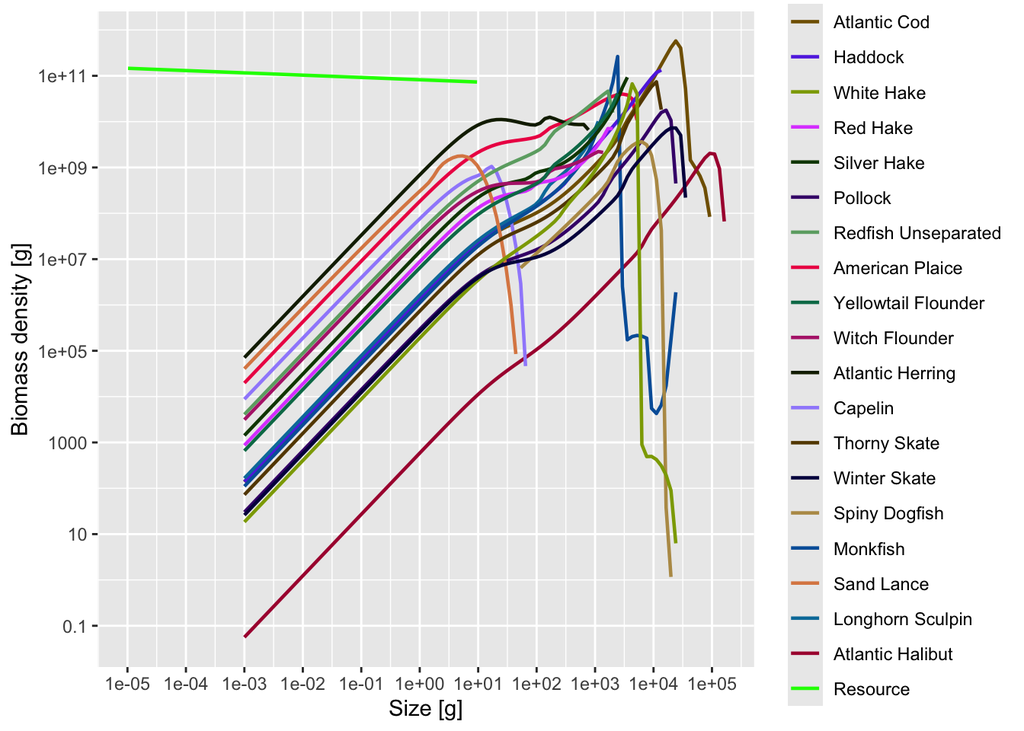

```r
# Plot the model spectra (biomass across size classes for all species and resource)
# - power = 2: scales the abundance spectrum to biomass (N(w) * w^2)
# Useful to assess size structure and whether any species dominate unrealistically
plotSpectra(params, power = 2)
```

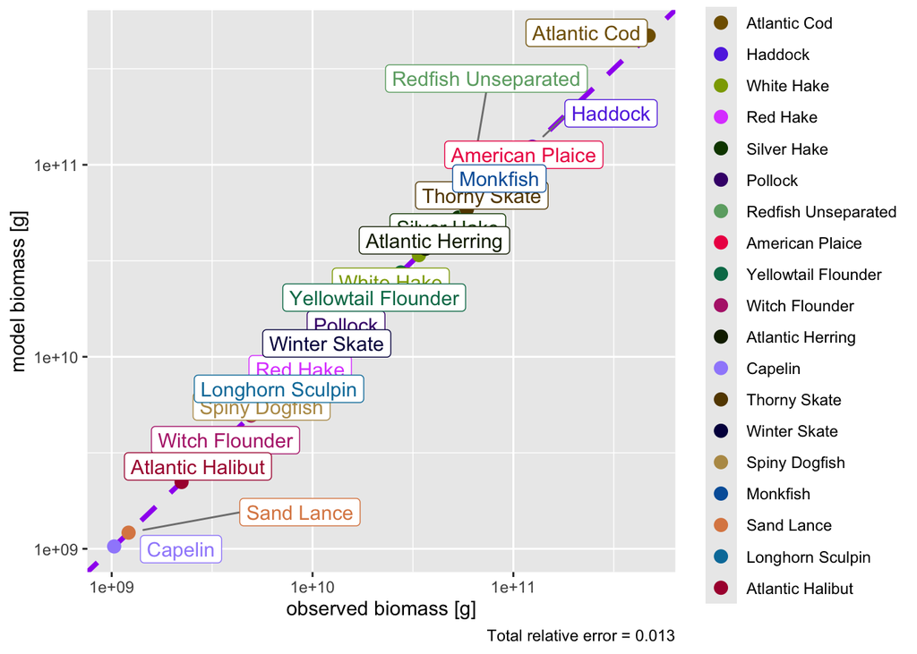

```r
# Plot model-predicted vs observed biomass (log-log scale by default)
# - ratio = FALSE (default): shows raw predicted vs observed biomass for each species
# Ideal results lie close to the 1:1 diagonal line
plotBiomassObservedVsModel(params)
```

# Set Sensitivity to Fishing

Check how model responses to fishing - resilience to fishing is influenced by the reproduction paramters being estimated by the steps above….

- need to check Fvsyield curves(and other plots)

Check YieldvsF plots for each species, ensuring dome shaped and ideally a peak yield roughly around expected single-species Fmsy

```r
library(gridExtra)
```

```r
specs  <- unique(species_params(params)$species)
plots  <- lapply(seq_along(specs), function(i) plotYieldVsF(params, species = i))
```

[output not shown]

[output not shown]

[output not shown]

[output not shown]

[output not shown]

[output not shown]

[output not shown]

[output not shown]

[output not shown]

[output not shown]

[output not shown]

[output not shown]

[output not shown]

[output not shown]

[output not shown]

[output not shown]

[output not shown]

[output not shown]

[output not shown]

[output not shown]

[output not shown]

[output not shown]

[output not shown]

[output not shown]

[output not shown]

[output not shown]

[output not shown]

[output not shown]

[output not shown]

[output not shown]

[output not shown]

[output not shown]

[output not shown]

[output not shown]

[output not shown]

[output not shown]

[output not shown]

[output not shown]

[output not shown]

[output not shown]

[output not shown]

[output not shown]

[output not shown]

[output not shown]

[output not shown]

[output not shown]

[output not shown]

[output not shown]

[output not shown]

[output not shown]

[output not shown]

[output not shown]

[output not shown]

[output not shown]

[output not shown]

[output not shown]

[output not shown]

[output not shown]

[output not shown]

[output not shown]

[output not shown]

[output not shown]

[output not shown]

[output not shown]

[output not shown]

[output not shown]

[output not shown]

[output not shown]

[output not shown]

[output not shown]

[output not shown]

[output not shown]

[output not shown]

[output not shown]

[output not shown]

[output not shown]

[output not shown]

[output not shown]

[output not shown]

[output not shown]

[output not shown]

[output not shown]

[output not shown]

[output not shown]

[output not shown]

[output not shown]

[output not shown]

[output not shown]

[output not shown]

[output not shown]

[output not shown]

[output not shown]

[output not shown]

[output not shown]

[output not shown]

[output not shown]

[output not shown]

[output not shown]

[output not shown]

[output not shown]

[output not shown]

[output not shown]

[output not shown]

[output not shown]

[output not shown]

[output not shown]

[output not shown]

[output not shown]

[output not shown]

[output not shown]

[output not shown]

[output not shown]

[output not shown]

[output not shown]

[output not shown]

[output not shown]

[output not shown]

[output not shown]

[output not shown]

[output not shown]

[output not shown]

[output not shown]

[output not shown]

[output not shown]

[output not shown]

[output not shown]

[output not shown]

[output not shown]

[output not shown]

[output not shown]

[output not shown]

[output not shown]

[output not shown]

[output not shown]

[output not shown]

[output not shown]

[output not shown]

[output not shown]

[output not shown]

[output not shown]

[output not shown]

[output not shown]

[output not shown]

[output not shown]

[output not shown]

[output not shown]

[output not shown]

[output not shown]

[output not shown]

[output not shown]

[output not shown]

[output not shown]

[output not shown]

[output not shown]

[output not shown]

[output not shown]

[output not shown]

[output not shown]

[output not shown]

[output not shown]

[output not shown]

[output not shown]

[output not shown]

[output not shown]

[output not shown]

[output not shown]

[output not shown]

[output not shown]

[output not shown]

[output not shown]

[output not shown]

[output not shown]

[output not shown]

[output not shown]

[output not shown]

[output not shown]

[output not shown]

[output not shown]

[output not shown]

[output not shown]

[output not shown]

[output not shown]

[output not shown]

[output not shown]

[output not shown]

[output not shown]

[output not shown]

[output not shown]

[output not shown]

[output not shown]

[output not shown]

[output not shown]

[output not shown]

[output not shown]

[output not shown]

[output not shown]

[output not shown]

[output not shown]

[output not shown]

[output not shown]

[output not shown]

[output not shown]

[output not shown]

[output not shown]

[output not shown]

[output not shown]

[output not shown]

[output not shown]

[output not shown]

[output not shown]

[output not shown]

[output not shown]

[output not shown]

[output not shown]

[output not shown]

[output not shown]

[output not shown]

[output not shown]

[output not shown]

[output not shown]

[output not shown]

[output not shown]

[output not shown]

[output not shown]

[output not shown]

[output not shown]

[output not shown]

[output not shown]

[output not shown]

[output not shown]

[output not shown]

[output not shown]

[output not shown]

[output not shown]

[output not shown]

[output not shown]

[output not shown]

[output not shown]

[output not shown]

[output not shown]

[output not shown]

[output not shown]

[output not shown]

[output not shown]

[output not shown]

[output not shown]

[output not shown]

[output not shown]

[output not shown]

[output not shown]

[output not shown]

[output not shown]

[output not shown]

[output not shown]

[output not shown]

[output not shown]

[output not shown]

[output not shown]

[output not shown]

[output not shown]

[output not shown]

[output not shown]

[output not shown]

[output not shown]

[output not shown]

[output not shown]

[output not shown]

[output not shown]

[output not shown]

[output not shown]

[output not shown]

[output not shown]

[output not shown]

[output not shown]

[output not shown]

[output not shown]

[output not shown]

[output not shown]

[output not shown]

[output not shown]

[output not shown]

[output not shown]

[output not shown]

[output not shown]

[output not shown]

[output not shown]

[output not shown]

[output not shown]

[output not shown]

[output not shown]

[output not shown]

[output not shown]

[output not shown]

[output not shown]

[output not shown]

[output not shown]

[output not shown]

[output not shown]

[output not shown]

[output not shown]

[output not shown]

[output not shown]

[output not shown]

[output not shown]

[output not shown]

[output not shown]

[output not shown]

[output not shown]

[output not shown]

[output not shown]

[output not shown]

[output not shown]

[output not shown]

[output not shown]

[output not shown]

[output not shown]

[output not shown]

[output not shown]

[output not shown]

[output not shown]

[output not shown]

[output not shown]

[output not shown]

[output not shown]

[output not shown]

[output not shown]

[output not shown]

[output not shown]

[output not shown]

[output not shown]

[output not shown]

[output not shown]

[output not shown]

[output not shown]

[output not shown]

[output not shown]

[output not shown]

[output not shown]

[output not shown]

[output not shown]

[output not shown]

[output not shown]

[output not shown]

[output not shown]

[output not shown]

[output not shown]

[output not shown]

[output not shown]

[output not shown]

[output not shown]

[output not shown]

[output not shown]

[output not shown]

[output not shown]

[output not shown]

[output not shown]

[output not shown]

[output not shown]

[output not shown]

[output not shown]

[output not shown]

[output not shown]

[output not shown]

[output not shown]

[output not shown]

[output not shown]

[output not shown]

[output not shown]

[output not shown]

[output not shown]

[output not shown]

[output not shown]

[output not shown]

[output not shown]

[output not shown]

[output not shown]

[output not shown]

[output not shown]

[output not shown]

[output not shown]

[output not shown]

[output not shown]

[output not shown]

[output not shown]

[output not shown]

[output not shown]

[output not shown]

[output not shown]

[output not shown]

[output not shown]

[output not shown]

[output not shown]

[output not shown]

[output not shown]

[output not shown]

[output not shown]

[output not shown]

[output not shown]

[output not shown]

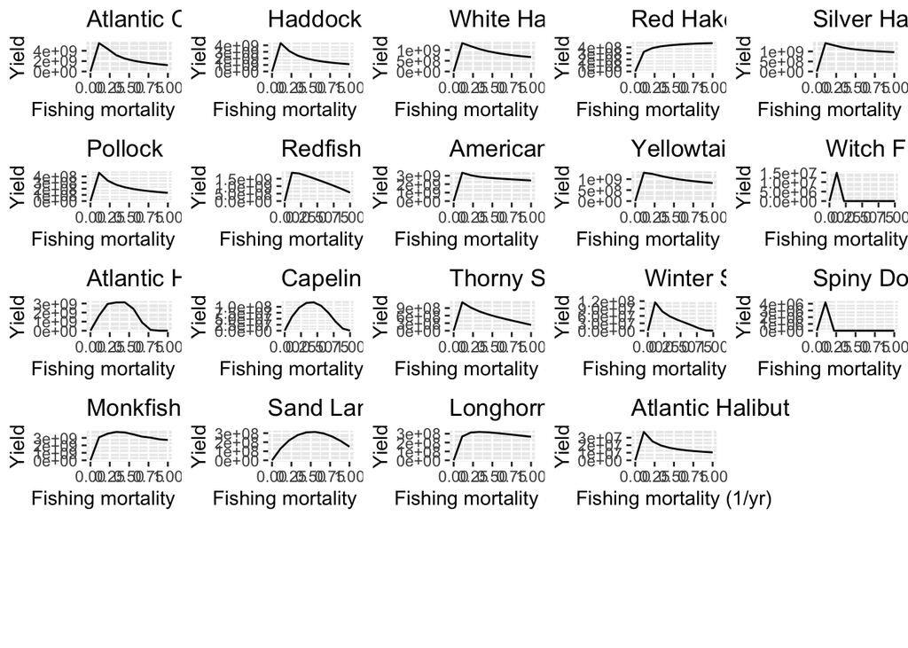

```r
# Display all 16 in a 4×4 grid (adjust if you have 19 species)
grid.arrange(grobs = plots[1:19], nrow = 5, ncol = 5)
```

## SEAL CATCHABILITY TUNING

```r
# ── SEAL CATCHABILITY TUNING ──────────────────────────────────────────────────
# Run AFTER initial matchBiomasses loop, BEFORE matchYield
seal_abundance   <- readRDS("Ess_data/seal_abundance_digitised.RDS")
ref_years        <- 1978:1985
ref_n_seals      <- mean(seal_abundance$scotian_mean[seal_abundance$year %in% ref_years]) * 1000

seal_body_mass_g       <- 200 * 1000    # *** VERIFY: Bundy 2004 uses ~170 kg ***
total_biomass_g        <- ref_n_seals * seal_body_mass_g
QB_seal                <- 12.98         # *** VERIFY against Bundy 2004 ***
fish_fraction          <- 0.85
Yield_observed_seals_g <- total_biomass_g * QB_seal * fish_fraction

seal_gear_name <- "Seals"

get_seal_yield <- function(p) {
  sum(sapply(species_params(p)$species, function(sp) {
    n <- initialN(p)[sp, ]
    f <- getFMortGear(p)[seal_gear_name, sp, ]
    sum(f * n * p@w * p@dw)
  }), na.rm = TRUE)
}

current_seal_total <- get_seal_yield(params)

scale_factor <- Yield_observed_seals_g / current_seal_total

seal_rows <- which(gear_params(params)$gear == seal_gear_name)
gear_params(params)$catchability[seal_rows] <- gear_params(params)$catchability[seal_rows] * scale_factor

params <- steady(params)
```

```
## Simulation run did not converge after 99 years. Value returned by the distance function was: 0.0136549073113217
```

-Check ratio between modelled and obs catches, rescale catchability -Adjust catchability, then setady state again

```r
## Adjust catchabilities and check yields
for ( i in 1:20){
params_my<- params |> matchYield(keep="biomass") |> matchBiomasses() |> steady()
}
```

```
## Convergence was achieved in 55.5 years.
```

```
## Convergence was achieved in 55.5 years.
```

```
## Convergence was achieved in 55.5 years.
```

```
## Convergence was achieved in 55.5 years.
```

```
## Convergence was achieved in 55.5 years.
```

```
## Convergence was achieved in 55.5 years.
```

```
## Convergence was achieved in 55.5 years.
```

```
## Convergence was achieved in 55.5 years.
```

```
## Convergence was achieved in 55.5 years.
```

```
## Convergence was achieved in 55.5 years.
```

```
## Convergence was achieved in 55.5 years.
```

```
## Convergence was achieved in 55.5 years.
```

```
## Convergence was achieved in 55.5 years.
```

```
## Convergence was achieved in 55.5 years.
```

```
## Convergence was achieved in 55.5 years.
```

```
## Convergence was achieved in 55.5 years.
```

```
## Convergence was achieved in 55.5 years.
```

```
## Convergence was achieved in 55.5 years.
```

```
## Convergence was achieved in 55.5 years.
```

```
## Convergence was achieved in 55.5 years.
```

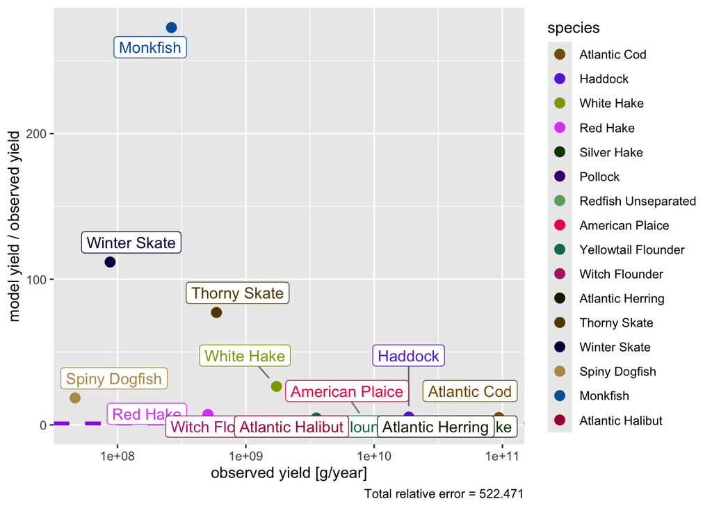

```r
plotYieldObservedVsModel(params_my,ratio=T)
```

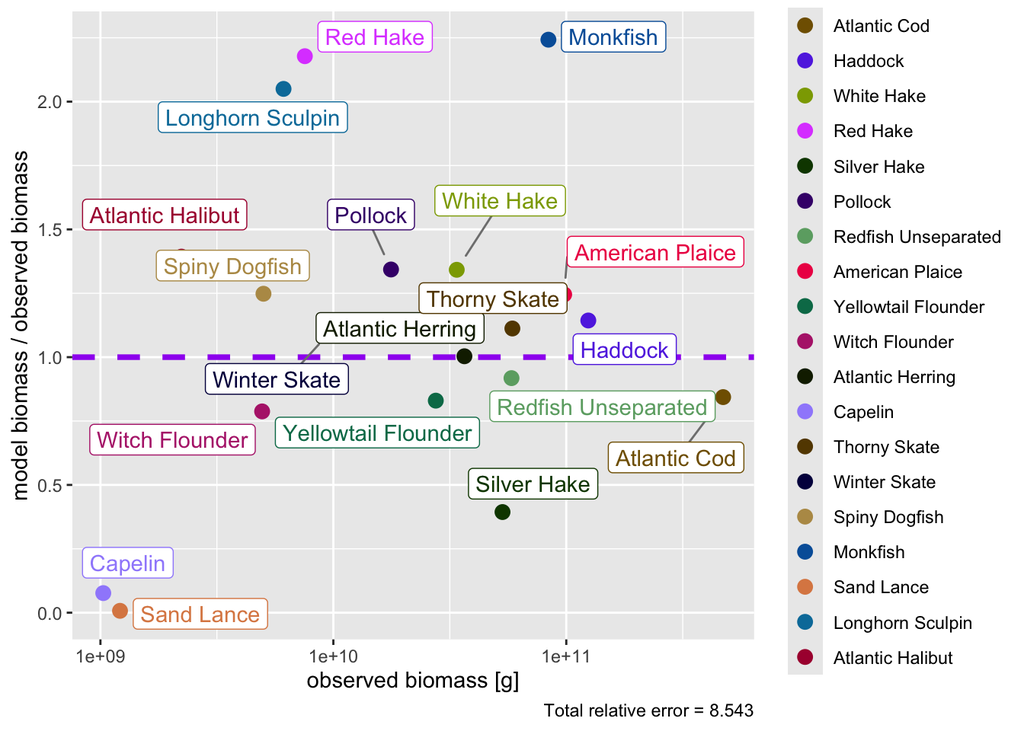

```r
plotBiomassObservedVsModel(params_my,ratio=T)
```

```r
# then re-do matchBiomasses separately
for ( i in 1:15){
params_my<- params_my |> matchBiomasses() |> steady()
}
```

```
## Convergence was achieved in 48 years.
```

```
## Convergence was achieved in 15 years.
```

```
## Convergence was achieved in 15 years.
```

```
## Convergence was achieved in 10.5 years.
```

```
## Convergence was achieved in 9 years.
```

```
## Convergence was achieved in 6 years.
```

```
## Convergence was achieved in 4.5 years.
```

```
## Convergence was achieved in 3 years.
```

```
## Convergence was achieved in 1.5 years.
```

```
## Convergence was achieved in 1.5 years.
```

```
## Convergence was achieved in 1.5 years.
```

```
## Convergence was achieved in 1.5 years.
```

```
## Convergence was achieved in 1.5 years.
```

```
## Convergence was achieved in 1.5 years.
```

```
## Convergence was achieved in 1.5 years.
```

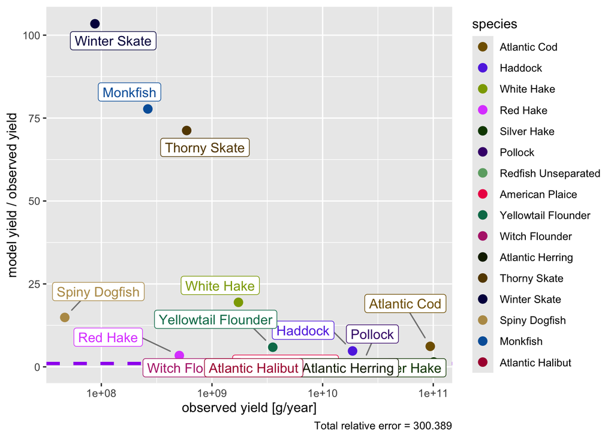

```r
plotYieldObservedVsModel(params_my,ratio=T)
```

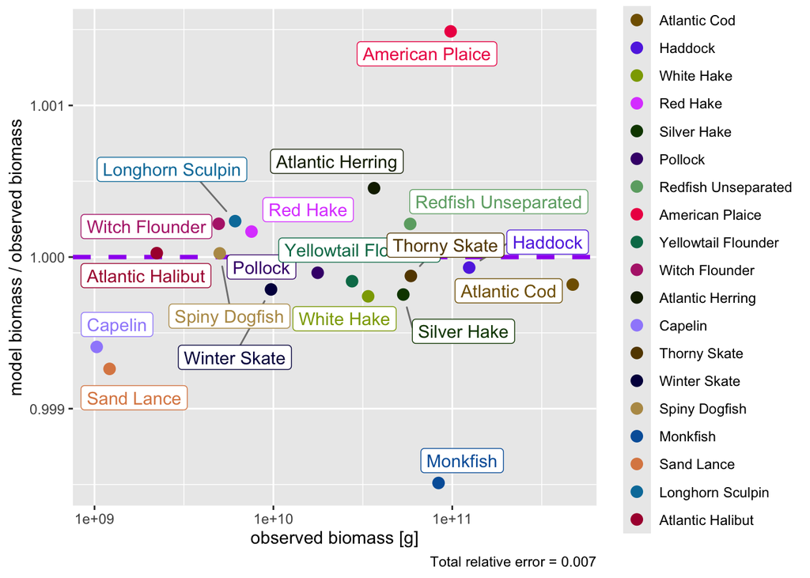

```r
plotBiomassObservedVsModel(params_my,ratio=T)
```

```r
#check approx fishing mort not unrealistically large or small
params_my@initial_effort[gear_params(params_my)$gear]*gear_params(params_my)$catchability
```

```
## Bottom_Trawl Bottom_Trawl   Fixed_Gear   Small_Mesh   Small_Mesh Bottom_Trawl
## 1.858224e-01 2.515718e-01 6.048061e-02 1.709907e-01 6.780942e+00 1.225945e+00
## Bottom_Trawl Bottom_Trawl Bottom_Trawl Bottom_Trawl      Pelagic      Pelagic
## 3.545076e-01 1.413071e-01 6.325758e-01 3.498375e-01 4.720891e-01 0.000000e+00
## Bottom_Trawl Bottom_Trawl   Fixed_Gear Bottom_Trawl Bottom_Trawl Bottom_Trawl
## 2.437389e-02 9.911888e-03 1.984266e-01 3.249181e-03 0.000000e+00 0.000000e+00
##   Fixed_Gear        Seals        Seals        Seals        Seals        Seals
## 6.563576e-01 1.102680e+01 1.273579e+00 8.971883e-02 1.589820e-02 1.166957e+01
##        Seals        Seals        Seals        Seals        Seals        Seals
## 1.021135e+00 1.896317e+00 1.846713e+00 6.049626e+00 6.547485e-01 7.610324e+00
##        Seals        Seals        Seals        Seals        Seals        Seals
## 0.000000e+00 3.603301e-01 1.404164e-01 1.720834e-02 1.304040e+06 0.000000e+00
##        Seals        Seals
## 0.000000e+00 4.486939e+05
```

```r
plotlyFMort(params_my)
```

[interactive chart not shown]

```r
## need to reduce catchability  ?

## scale down fishing mortalities - careful only do this ONCE IF NEEDED
 select<-params_my@initial_effort[gear_params(params_my)$gear]*gear_params(params_my)$catchability > 1

 gear_params(params_my)$catchability[select==T]<-gear_params(params_my)$catchability[select==T]/c(4,1.4,2,2)

 params_steady<- params_my |> steady()
```

```
## Convergence was achieved in 45 years.
```

```r
 plotlyFMort(params_steady)
```

[interactive chart not shown]

```r
##repeat until convergence 1.5 years, then check Fmort and other above plots
 for (i in 1:25) {
 params_steady<- params_steady |> matchBiomasses() |> steady()
 }
```

```
## Convergence was achieved in 21 years.
```

```
## Convergence was achieved in 18 years.
```

```
## Convergence was achieved in 15 years.
```

```
## Convergence was achieved in 10.5 years.
```

```
## Convergence was achieved in 7.5 years.
```

```
## Convergence was achieved in 3 years.
```

```
## Convergence was achieved in 1.5 years.
```

```
## Convergence was achieved in 1.5 years.
```

```
## Convergence was achieved in 1.5 years.
## Convergence was achieved in 1.5 years.
## Convergence was achieved in 1.5 years.
## Convergence was achieved in 1.5 years.
## Convergence was achieved in 1.5 years.
## Convergence was achieved in 1.5 years.
## Convergence was achieved in 1.5 years.
## Convergence was achieved in 1.5 years.
## Convergence was achieved in 1.5 years.
## Convergence was achieved in 1.5 years.
## Convergence was achieved in 1.5 years.
## Convergence was achieved in 1.5 years.
## Convergence was achieved in 1.5 years.
## Convergence was achieved in 1.5 years.
## Convergence was achieved in 1.5 years.
## Convergence was achieved in 1.5 years.
## Convergence was achieved in 1.5 years.
```

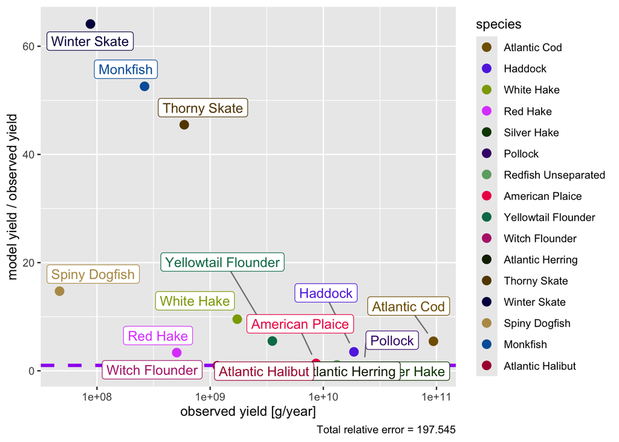

```r
 plotYieldObservedVsModel(params_steady,ratio=T)
```

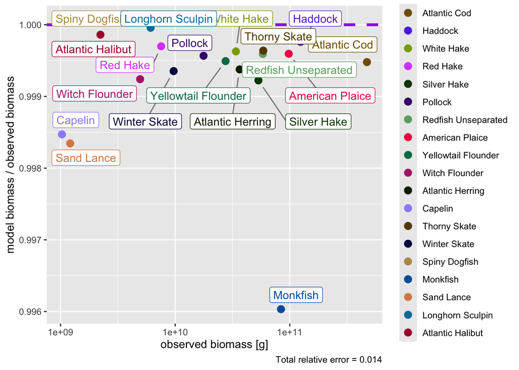

```r
 plotBiomassObservedVsModel(params_steady,ratio=T)
```

```r
 plotlyFMort(params_steady)
```

[interactive chart not shown]

## Diagnostics: Now check steady state, again

```r
# Run the model to steady state and return the full simulation object
# - return_sim = TRUE: keeps the time series data (vs. just returning final params)
# - t_max = 100: allows up to 100 time steps to reach convergence
sim <- steady(params_steady, return_sim = TRUE, t_max = 100)
```

```
## Convergence was achieved in 1.5 years.
```

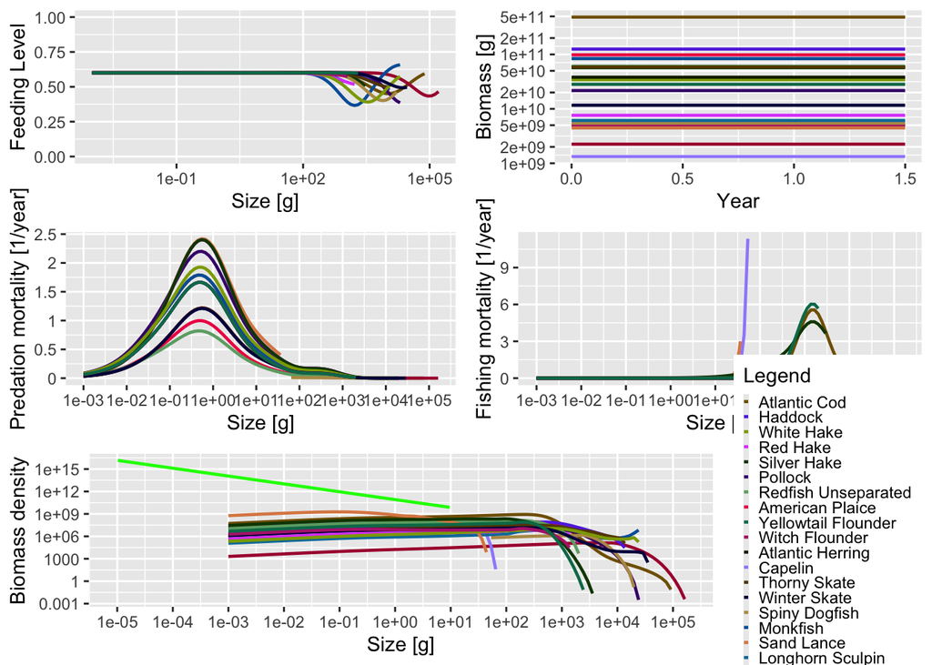

```r
# Quick plot of total biomass and yields over time (main summary)
plot(sim)
```

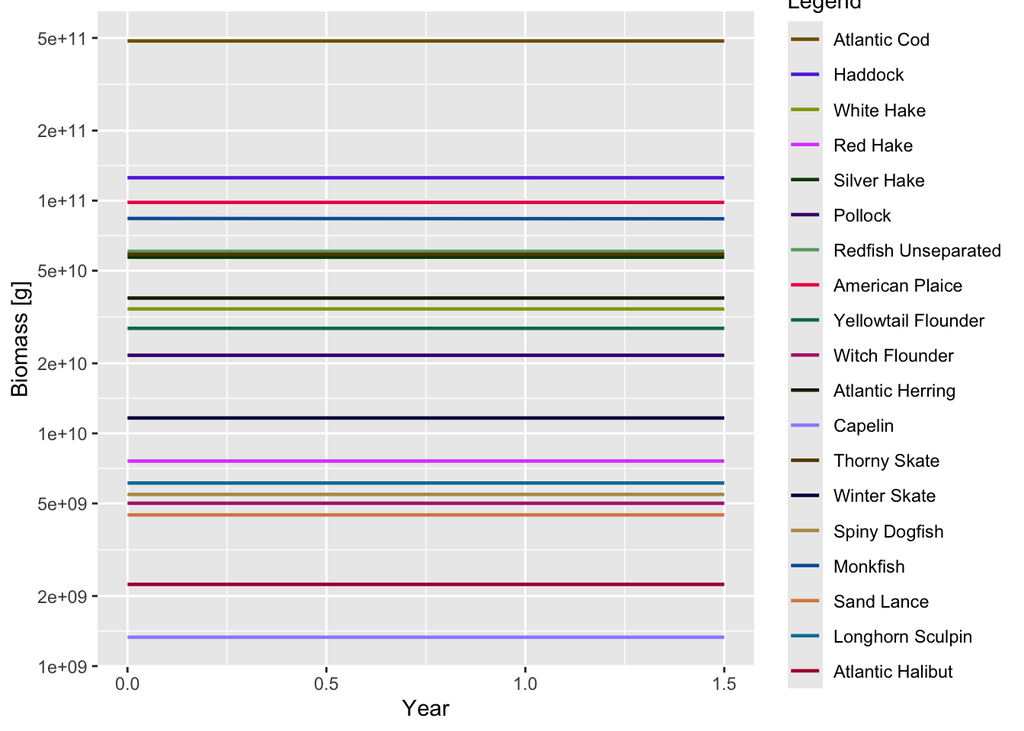

```r
# Check Diagnostic plots
# Plot species biomass over time
# Useful to check if species stabilize or fluctuate at steady state
plotBiomass(sim)
```

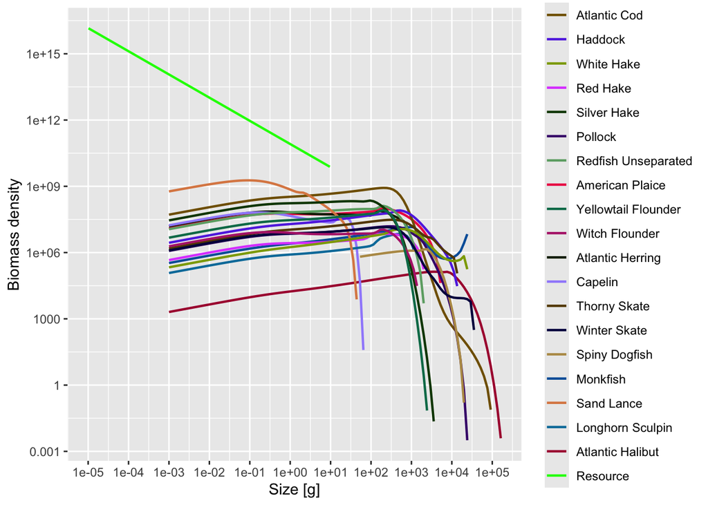

```r
# Plot spectra (biomass by size) from the final state
# Reveals trophic structure and size-based energy flow
plotSpectra(sim)
```

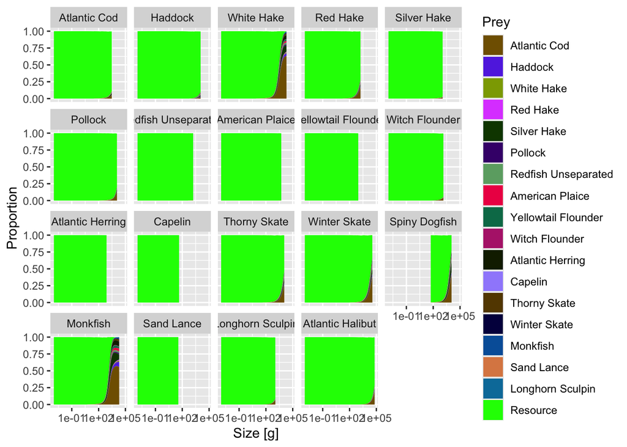

```r
# Plot species diet composition by size
# Shows who eats whom across size classes
plotDiet(params_steady)
```

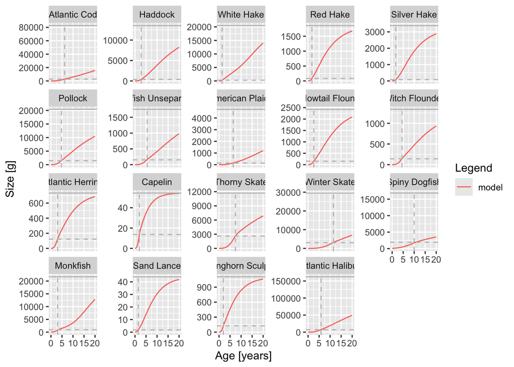

```r
# Plot growth curves for each species
# - species_panel = TRUE: shows separate panels per species
# - max_age = 20: restricts plots to ages up to 20
plotGrowthCurves(params_steady, species_panel = TRUE, max_age = 20)
```

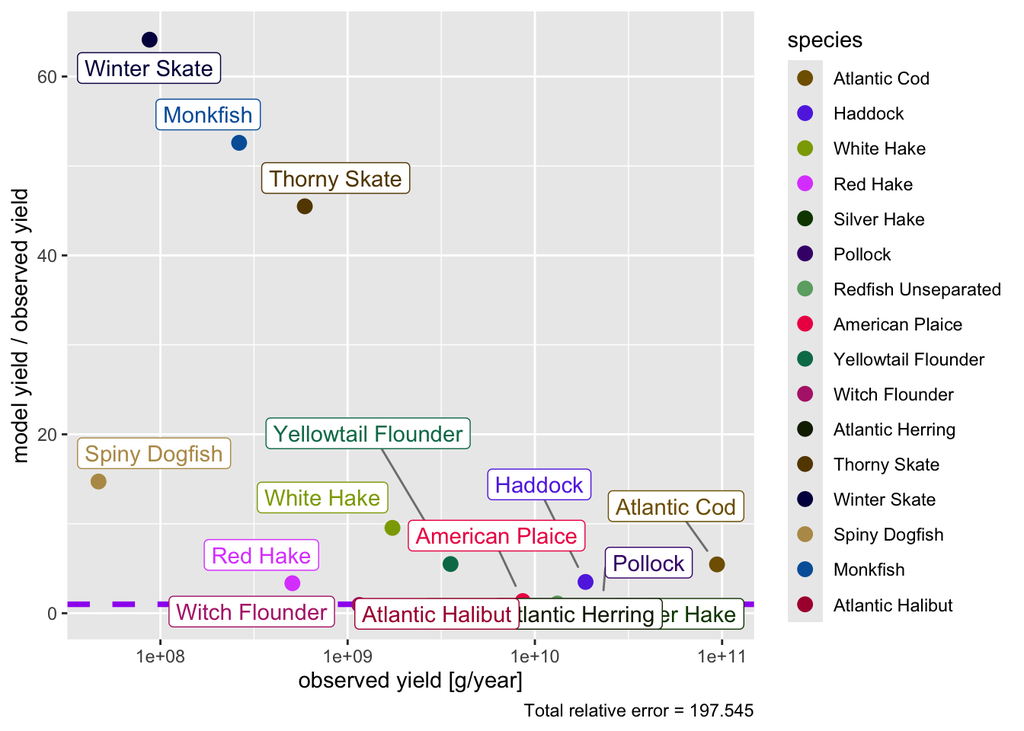

```r
# Compare model vs observed yield (catch)
# - ratio = TRUE: visualizes model/observed ratio; ideal = 1
plotYieldObservedVsModel(params_steady, ratio = TRUE)
```

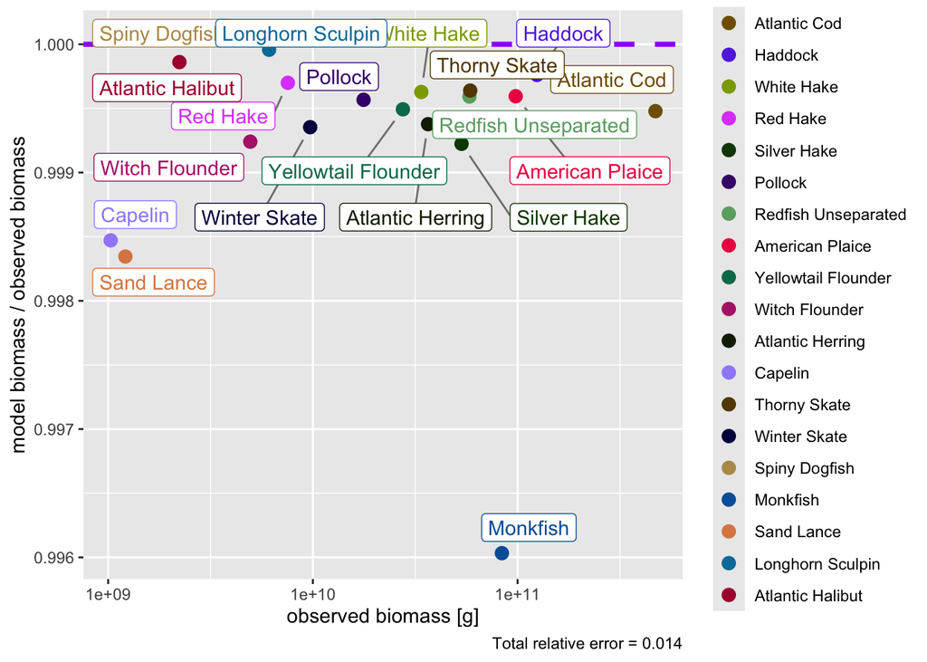

```r
# Compare model vs observed biomass
# - ratio = TRUE: visualizes model/observed ratio; ideal = 1
plotBiomassObservedVsModel(params_steady, ratio = TRUE)
```

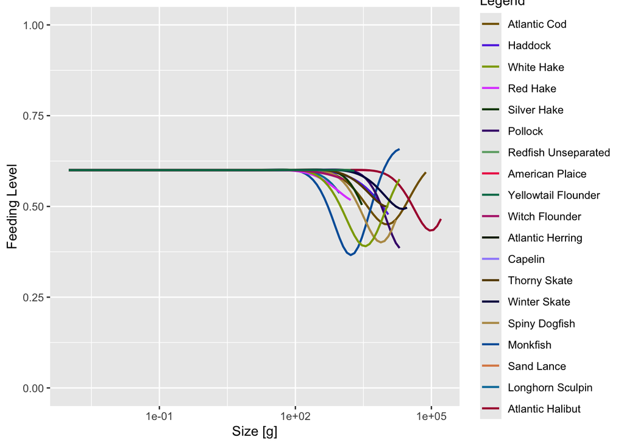

```r
# Plot feeding level by size
# Reveals how full each species is at each size (0 = starving, 1 = satiated)
plotFeedingLevel(params_steady)
```

# Examining Growth curves for supplements

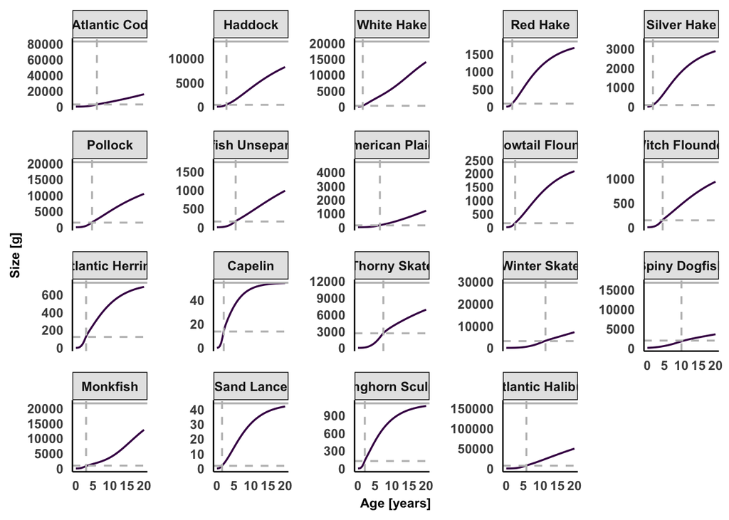

```r
GrowthCurves <- plotGrowthCurves(params_steady, species_panel = TRUE, max_age = 20) +
  theme_minimal(base_size = 14) +
  scale_color_viridis_d() +
  labs(
    x = "Age (Years)",
    y = "Size (g)") +
  theme(
    panel.grid       = element_blank(),
    panel.spacing    = unit(1, "lines"),
    strip.text       = element_text(size = 9, face = "bold"),
    strip.background = element_rect(fill = "grey90", color = "black", linewidth = 0.5),
    axis.text        = element_text(size = 9, face = "bold"),
    axis.title       = element_text(size = 9, face = "bold"),
    axis.line        = element_line(color = "black", linewidth = 0.5),
    legend.position  = "none") + facet_wrap(~Species, scales = "free_y")

GrowthCurves
```

```r
ggsave(filename = paste0(save_dir, "GrowthCurves.jpeg"), plot = GrowthCurves,
       width = 11, height = 8.5, units = "in",dpi = 400)
```

Check diet proportions of each species in predator diets, can compare with Table 4.1.1.1 in Cook & Bundy 2010 DFO report

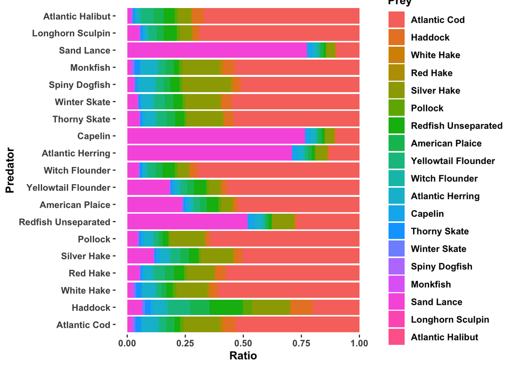

```r
#Calculate proportion of each species in each species diet across pred and prey  sizes
diet <- data.frame(
  melt( apply(getDiet(params_steady)[, which(params_steady@w > 10), 1:19], c(1, 3), sum) /
      rowSums(apply(getDiet(params_steady)[, which(params_steady@w > 10), 1:19], c(1, 3), sum)[, ])))

levels(diet$predator) <- c(
  "Atlantic Cod", "Haddock", "White Hake", "Red Hake", "Silver Hake", "Pollock",
  "Redfish Unseparated", "American Plaice", "Yellowtail Flounder", "Witch Flounder",
  "Atlantic Herring", "Capelin", "Thorny Skate", "Winter Skate", "Spiny Dogfish",
  "Monkfish", "Sand Lance", "Longhorn Sculpin", "Atlantic Halibut")

diet <- diet |> rename(Prey = prey, Predator = predator, Ratio = value)
diet_interaction <- ggplot(diet, aes(fill = Prey, x = Predator, y = Ratio)) +
  geom_bar(position = "stack", stat = "identity") +
  coord_flip() +
  theme(
    panel.background = element_blank(),
    plot.background  = element_blank(),
    axis.title       = element_text(face = "bold", size = 11),
    axis.text        = element_text(face = "bold", size = 9),
    legend.text      = element_text(face = "bold", size = 9),
    legend.title     = element_text(face = "bold", size = 11)
  ) + labs(x = "Predator", y = "Ratio")

diet_interaction
```

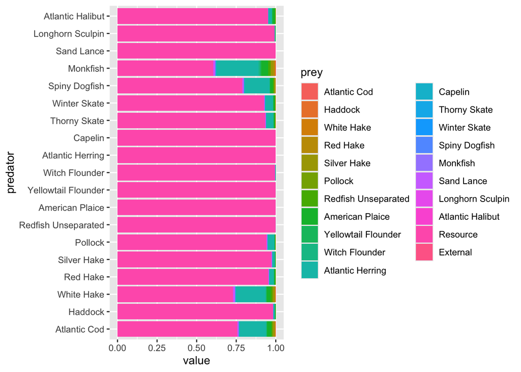

```r
ggsave(filename = paste0(save_dir, "diet_interaction.jpeg"), plot = diet_interaction,
       width = 11, height = 8.5, units = "in", dpi = 400)

# Diet including resource
diet_full <- data.frame(melt(apply(getDiet(params)[, which(params@w > 10), ], c(1, 3), sum) / rowSums(apply(getDiet(params)[, which(params@w > 10), ], c(1, 3), sum)[, ])))

ggplot(diet_full, aes(fill = prey, x = predator, y = value)) +
  geom_bar(position = "stack", stat = "identity") + coord_flip()
```

Create size spectrum plots by species with size distribution data from DFO RV Trawl Surveys (q-corrected)

```r
stat <- read.csv("Ess_data/LF_Biomass_Abund.csv")
# ------------------------------------------------------------
# 1. Load and reshape biomass-at-length to long format
bio_size <- stat |> filter(YEAR >= 1978, YEAR <= 1985) |>
  select(Year = YEAR,species_name_raw = COMMON_NAME,
    length_cm = FLEN, Biomass = Biomass_Strata_KG) |>
  mutate(# Herring FLEN is in mm, convert once to cm
    length_cm = ifelse(species_name_raw == "HERRING(ATLANTIC)" & length_cm > 50,length_cm / 10,length_cm),
    Species = species_code_lookup[species_name_raw]) |>
  filter(!is.na(Species)) |> select(Year, Species, length_cm, Biomass)
# ------------------------------------------------------------
# 2. Check observed length range per species
# ------------------------------------------------------------
max_min_size <- bio_size |>
  group_by(Species) |>
  summarise(min_l = min(length_cm, na.rm = TRUE),max_l = max(length_cm, na.rm = TRUE),.groups = "drop")

print(max_min_size)
```

```
## # A tibble: 19 × 3
##    Species             min_l max_l
##    <chr>               <dbl> <dbl>
##  1 American Plaice         6    74
##  2 Atlantic Cod            4   142
##  3 Atlantic Halibut       18   160
##  4 Atlantic Herring        6    50
##  5 Capelin                12    15
##  6 Haddock                 3    83
##  7 Longhorn Sculpin        7    47
##  8 Monkfish               10   116
##  9 Pollock                 6   111
## 10 Red Hake                6    58
## 11 Redfish Unseparated     4    50
## 12 Sand Lance              4    28
## 13 Silver Hake             8    67
## 14 Spiny Dogfish          28   103
## 15 Thorny Skate            1   112
## 16 White Hake              4   123
## 17 Winter Skate           16   105
## 18 Witch Flounder          2    66
## 19 Yellowtail Flounder    10    54
```

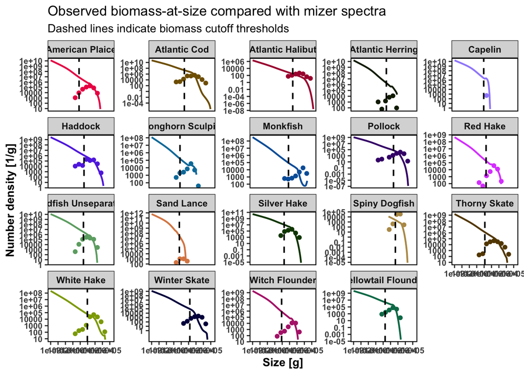

```r
# ------------------------------------------------------------
# 3. Join L-W parameters and compute weight
# ------------------------------------------------------------
wl <- data.frame(Species = species_params(params)$species,
                 a = species_params(params)$a,b = species_params(params)$b)

bio_size <- bio_size |> left_join(wl, by = "Species") |>
  mutate(  w = a * length_cm ^ b) |> filter(!is.na(Biomass), !is.na(w),w > 0)

# ------------------------------------------------------------
# 4. Bin into weight classes and normalise biomass
# ------------------------------------------------------------
breaks <- 10 ^ seq(0, 6, 0.5)
low    <- head(breaks, -1)
upp    <- tail(breaks, -1)
widths <- upp - low
mid    <- (low + upp) / 2

bio_size <- bio_size |> mutate(bin_id = as.integer(cut(w, breaks = breaks, include.lowest = TRUE)),
    weightclass = mid[bin_id],norm_biomass = Biomass / widths[bin_id]) |>
  filter( !is.na(weightclass),!is.na(norm_biomass),is.finite(norm_biomass))

write.csv(bio_size, "Ess_data/bio_size.csv", row.names = FALSE)
# ------------------------------------------------------------
# 5. Summarise: normalised biomass per weight class x year x species
# ------------------------------------------------------------
biomass_size_spectra <- bio_size |> group_by(weightclass, Year, Species) |>
  summarise(nbiomass = sum(norm_biomass, na.rm = TRUE),.groups = "drop" )

mean_biomass_size_spectra <- biomass_size_spectra |>
  group_by(weightclass, Species) |>
  summarise( mean_nbiomass = mean(nbiomass, na.rm = TRUE),.groups = "drop")

# ------------------------------------------------------------
# 6. Plot: mizer spectra + observed biomass size spectra
# ------------------------------------------------------------

# ------------------------------------------------------------
# Biomass cutoff lines
# ------------------------------------------------------------
cutoff_lines <- external_species_info |>
  select(Species = species,biomass_cutoff) |> filter(!is.na(biomass_cutoff))

size_distributions <- plotSpectra( params_steady,power = 0,resource = FALSE) +

  # observed spectra
  geom_point(data = mean_biomass_size_spectra,
    aes( x = weightclass,y = mean_nbiomass, colour = Species),inherit.aes = FALSE) +
  # biomass cutoff thresholds
  geom_vline(
    data = cutoff_lines, aes(xintercept = biomass_cutoff),
    linetype = "dashed", linewidth = 0.7,colour = "black",inherit.aes = FALSE) +
  facet_wrap(~Species, scales = "free_y") +
  labs(
    x = "Weight class (g)",y = "Normalised mean biomass",
    title = "Observed biomass-at-size compared with mizer spectra",
    subtitle = "Dashed lines indicate biomass cutoff thresholds") +
  theme_bw() +
  theme(
    legend.position = "none",
    axis.title.x = element_text(face = "bold"),
    axis.title.y = element_text(face = "bold"),
    strip.text = element_text(face = "bold"),
    axis.text.x = element_text(size = 8, face = "bold"),
    axis.text.y = element_text(size = 8, face = "bold"),
    panel.grid = element_blank(),
    panel.border = element_rect(color = "black", linewidth = 0.8) )

size_distributions
```

Plot Observed vs model calibration period

[figure not shown]

```r
yield_steady<-plotYieldObservedVsModel(params_steady, return_data=T)
r_yield<-cor(yield_steady$model,yield_steady$observed,method="spearman")

Calibration_plot_yield <- plotYieldObservedVsModel(params_steady, ratio = FALSE, labels = F)+
theme_bw() +
    ggtitle("Catch") +  # Adding the title
    theme(
        plot.title = element_text(size = 10, face = "bold", hjust = 0.5),  # Centering the title
        axis.text.x = element_text(angle = 90, hjust = 1, vjust = 1, size = 8, face = "bold"),
        axis.text.y = element_text(size = 8, face = "bold"),  # Y-axis labels size 8
        axis.title.x = element_text(size = 10, face = "bold"),  # X-axis title size 8
        axis.title.y = element_text(size = 10, face = "bold"),  # Y-axis title size 8
        panel.grid.major.x = element_blank(),
        panel.grid.major.y = element_blank(),
        panel.grid.minor = element_blank(),
        panel.border = element_rect(color = "black", size = 0.5),
        legend.position = "none",  # No legend since all bars are blue
        panel.spacing = unit(0.5, "lines"),
        plot.margin = unit(c(0.5, 0.5, 0.5, 0.2), "cm"),
        aspect.ratio = 0.8) +
    geom_hline(yintercept = 0, color = "black", size = 0.1) +
  annotate("text", x = Inf, y = Inf, label = expression(bold("(a)")),
         parse = TRUE, size = 3, hjust = 21, vjust = 2.1) +
  annotate("text", x = Inf, y = Inf, label = expression(bold("r = 0.99")),
        parse = TRUE, size = 3, hjust = 1.1, vjust = 27.1)
Calibration_plot_yield
```